# Lab Assignment Six: Convolutional Network Architectures

### (AlexNet) Visualize the training and validation f1_score and loss of each iteration of every fold

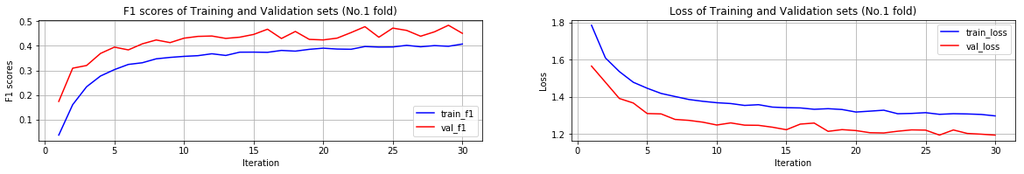

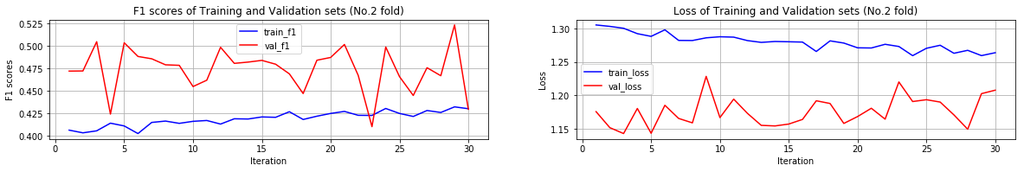

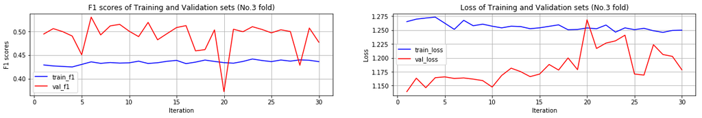

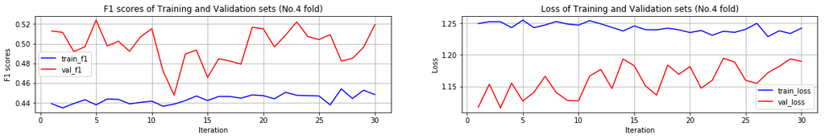

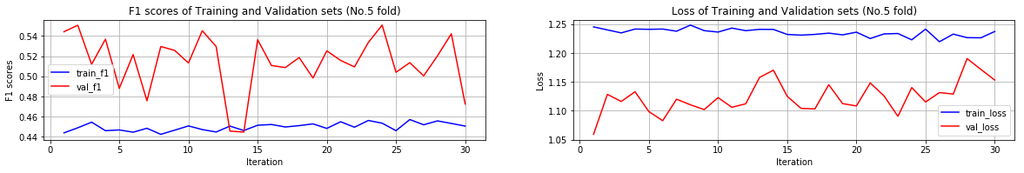

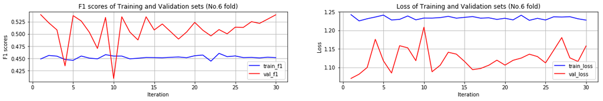

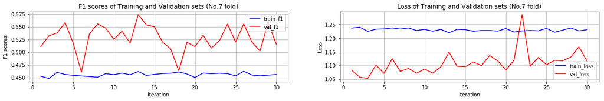

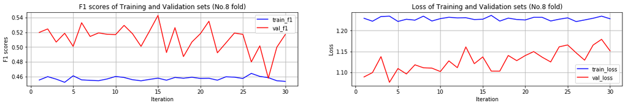

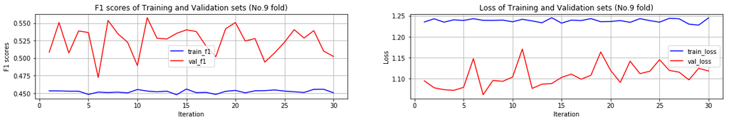

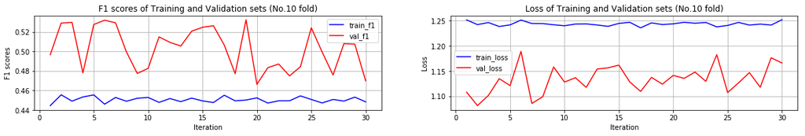

```python
# there are 10 folds, so there are 10 groups of data
for i in range(0, len(cv_training_f1_score)):
    iteration = range(1,len(cv_training_f1_score[i])+1)
    plt.figure(figsize=(20,30))
    plt.subplot(10,2,1)
    plt.plot(iteration, cv_training_f1_score[i], linestyle='-', color='blue', label='train_f1')
    plt.plot(iteration, cv_val_f1_score[i], linestyle='-', color='red', label='val_f1')
    plt.grid()
    plt.legend()
    plt.xlabel('Iteration')
    plt.ylabel('F1 scores')
    plt.title('F1 scores of Training and Validation sets (No.%.0f fold)' % (i+1))

    plt.subplot(10,2,2)
    plt.plot(iteration, cv_training_loss[i], linestyle='-', color='blue', label='train_loss')
    plt.plot(iteration, cv_val_loss[i], linestyle='-', color='red', label='val_loss')
    plt.grid()
    plt.legend()
    plt.xlabel('Iteration')
    plt.ylabel('Loss')
    plt.title('Loss of Training and Validation sets (No.%.0f fold)' % (i+1))
```

```python
iteration = np.array([i for i in range(1, len(cv_training_f1_score[0])+1)])

cv_training_f1_score_mean = np.mean(np.array(cv_training_f1_score), axis=0)
cv_training_f1_score_std = np.std(np.array(cv_training_f1_score), axis=0)

cv_training_loss_mean = np.mean(np.array(cv_training_loss), axis=0)
cv_training_loss_std = np.std(np.array(cv_training_loss), axis=0)

cv_val_f1_score_mean = np.mean(np.array(cv_val_f1_score), axis=0)
cv_val_f1_score_std = np.std(np.array(cv_val_f1_score), axis=0)

cv_val_loss_mean = np.mean(np.array(cv_val_loss), axis=0)
cv_val_loss_std = np.std(np.array(cv_val_loss), axis=0)
```

```
Text(0.5,1,'Loss vs. Iterations')
```

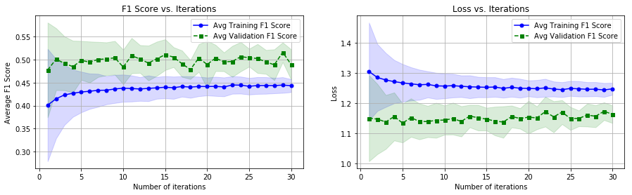

```python
plt.figure(figsize=(15,4))

plt.subplot(1,2,1)
plt.plot(iteration, cv_training_f1_score_mean, color='blue', marker='o', markersize=5, label='Avg Training F1 Score')
plt.fill_between(iteration, cv_training_f1_score_mean+cv_training_f1_score_std,
                 cv_training_f1_score_mean-cv_training_f1_score_std, alpha=0.15, color='blue')
plt.plot(iteration, cv_val_f1_score_mean, color='green', linestyle='--', marker='s', markersize=5, label='Avg Validation F1 Score')
plt.fill_between(iteration, cv_val_f1_score_mean+cv_val_f1_score_std,
                 cv_val_f1_score_mean-cv_val_f1_score_std, alpha=0.15, color='green')
plt.grid()
plt.xlabel('Number of iterations')
plt.ylabel('Average F1 Score')
plt.legend()
plt.title('F1 Score vs. Iterations')

plt.subplot(1,2,2)
plt.plot(iteration,cv_training_loss_mean, color='blue', marker='o', markersize=5, label='Avg Training F1 Score')
plt.fill_between(iteration, cv_training_loss_mean+cv_training_loss_std,
                 cv_training_loss_mean-cv_training_loss_std, alpha=0.15, color='blue')
plt.plot(iteration, cv_val_loss_mean, color='green', linestyle='--', marker='s', markersize=5, label='Avg Validation F1 Score')
plt.fill_between(iteration, cv_val_loss_mean+cv_val_loss_std,
                 cv_val_loss_mean-cv_val_loss_std, alpha=0.15, color='green')
plt.grid()
plt.xlabel('Number of iterations')
plt.ylabel('Loss')
plt.legend()
plt.title('Loss vs. Iterations')
```

We also calculate the average and standrad deviation of F1 score and average and standard deviation of loss for each iteration. Then visualize the average and standard deviation of F1 score and loss vs number of iterations. From above we can see, the f1 score of Alexnet model stays in 0.50 +- 0.05 and it's unstable compared the other two models. Compared to Xception and Resnet Architecture Model, the performance of Alexnet model is not good enough.

Overall, from the above three groups performance of Xeception architecture, ResNet architecture Alexnet Architecture, it looks like the ResNet performs a little better than the other two architectures. In the next section, we will not use data expansion to train different models and compare their performance using more visualizations.

## 2.3 Final Results of CNNs

#### [15 points] Visualize the final results of the CNNs and interpret the performance. Use proper statistics as appropriate, especially for comparing models.

```python
from sklearn.model_selection import train_test_split

X_train, X_test, y_train, y_test = train_test_split(X, y, test_size=0.2, stratify=y, random_state=6)

X_train = X_train/255.0 - 0.5
X_test = X_test/255.0 - 0.5

# NEW: Let's start by fixing the sizes
X_train = np.expand_dims(X_train.reshape((-1,img_wh,img_wh)), axis=3)
X_test = np.expand_dims(X_test.reshape((-1,img_wh,img_wh)), axis=3)
# the image data has been resized to (samples,image_rows,image_cols,image_channels)

# and one hot encoding the output values
y_train_ohe = keras.utils.to_categorical(y_train, NUM_CLASSES)
y_test_ohe = keras.utils.to_categorical(y_test, NUM_CLASSES)

print(X_train.shape)
print(X_test.shape)
```

```
(28709, 48, 48, 1)
(7178, 48, 48, 1)
```

```python
from sklearn.model_selection import StratifiedKFold
from sklearn import metrics as mt

alex_net.compile(loss='categorical_crossentropy', # 'categorical_crossentropy' 'mean_squared_error'
                 optimizer='rmsprop', # 'adadelta' 'rmsprop'
                 metrics=[f1])
resnet.compile(loss='categorical_crossentropy', # 'categorical_crossentropy' 'mean_squared_error'
               optimizer='adam', # 'adadelta' 'rmsprop'
               metrics=[f1])
xception_model.compile(loss='categorical_crossentropy', # 'categorical_crossentropy' 'mean_squared_error'
                       optimizer='adam', # 'adadelta' 'rmsprop'
                       metrics=[f1])
models = [alex_net, resnet, xception_model]

scores = []
for model in models:
    score_temp = []
    kFold = StratifiedKFold(n_splits=10, random_state=1).split(X_train, y_train)
    for k, (train, test) in enumerate(kFold):
        model.fit(X_train[train], y_train_ohe[train], epochs=30, batch_size=128, verbose=0)
        yhat = np.argmax(model.predict(X_train[test]), axis=1)
        score = mt.f1_score(y_train[test], yhat, average='macro')
        score_temp += [score]
    scores.append(score_temp)
```

This time, we use the original dataset instead of data expansion to train our three models using 10-fold cross validation. Then we save the results into a list which will be used for visualization later.  
For the f1_score calculation, we used metrics package from sklearn and we use macro technique for averaging f1 score because we don't have particular weight for each class, we treat every class equally.

```python
file = open('scores_dome5.txt','a')
for i in range(len(scores)):
    s = str(scores[i]).replace('[','').replace(']','')
    s = s.replace(',','') +'\n'
    file.write(s)
file.close()
```

[output not shown]

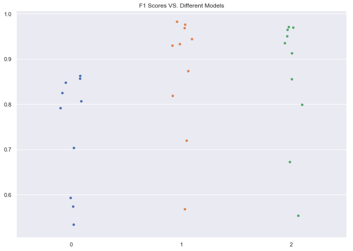

```python
file = open("scores_dome5.txt", 'r')
score_full = []
for line in file:
    line = line.replace('\n', '')
    score_temp = line.split(' ')
    score_full.append(list(map(lambda x: float(x), score_temp)))
file.close()
print(score_full)
```

We also plot a stripplot to show the performance of each fold of each model. In strriplot above, index 0 represents Alexnet, index 1 represents Resnet, index 2 represents Xception net. We can see, the resnet model performs obviously better than Alexnet model and performs slightly better than Xception model. Next we will use 20% unseen testing data to evaluate our models

```python
from sklearn import metrics as mt
from skimage.io import imshow
%matplotlib inline

def summarize_net(net, X_test, y_test):
    plt.figure(figsize=(15,5))
    yhat = np.argmax(net.predict(X_test), axis=1)
    f1_score = mt.f1_score(y_test, yhat, average='macro')
    return f1_score, y_test, yhat
```

#### Xception

```python
f1_score, y_test, yhat = summarize_net(xception_model, X_test, y_test)
y_test = [i for i in y_test]
y_hat = [i for i in yhat]
print(f1_score)
with open('xception_model_demo5.txt', 'a') as f:
    f.write(str(y_test).replace('[', '').replace(']', '').replace(',', '').strip())
    f.write('\n')
    f.write(str(y_hat).replace('[', '').replace(']', '').replace(',', '').strip())
```

```
0.5619280591014244
```

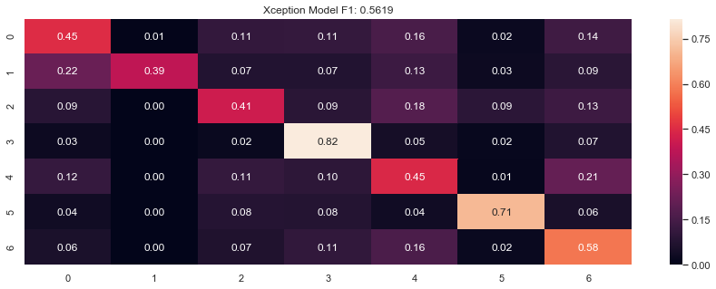

#### ResNet

```python
f1_score, y_test, yhat = summarize_net(resnet, X_test, y_test)
y_test = [i for i in y_test]
y_hat = [i for i in yhat]
print(f1_score)
with open('resnet_model_demo5.txt', 'a') as f:
    f.write(str(y_test).replace('[', '').replace(']', '').replace(',', '').strip())
    f.write('\n')
    f.write(str(y_hat).replace('[', '').replace(']', '').replace(',', '').strip())
```

```
0.5654372207269526
```

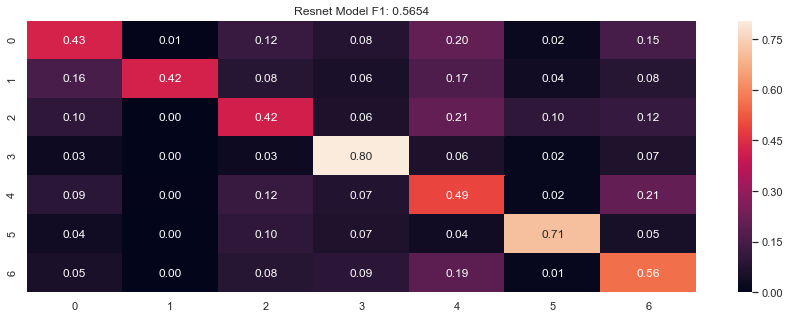

#### AlexNet

```python
f1_score, y_test, yhat = summarize_net(alex_net, X_test, y_test)
y_test = [i for i in y_test]
y_hat = [i for i in yhat]
print(f1_score)
with open('alexnet_model_demo5.txt', 'a') as f:
    f.write(str(y_test).replace('[', '').replace(']', '').replace(',', '').strip())
    f.write('\n')
    f.write(str(y_hat).replace('[', '').replace(']', '').replace(',', '').strip())
```

```
0.4864983002002684
```

[figure not shown]

```
Performance of Xception
loss : 1.3928804470324256
f1 : 0.5821781352756082


Performance of LeNet
loss : 1.5572802104734718
f1 : 0.5835275122733394


Performance of AlexNet
loss : 2.7670621885234317
f1 : 0.5321417802155399
```

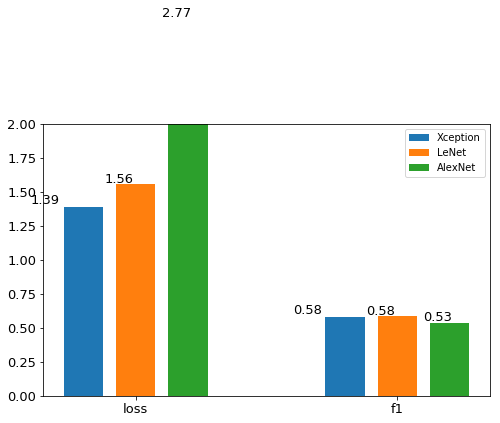

```python
xcep_performance = xception_model.evaluate(X_test, y_test_ohe)

print('Performance of Xception')
for i in range(len(xception_model.metrics_names)):
    print(xception_model.metrics_names[i], ': '+str(xcep_performance[i]))

print('\n')

res_performance = resnet.evaluate(X_test, y_test_ohe)
print('Performance of LeNet')
for i in range(len(resnet.metrics_names)):
    print(resnet.metrics_names[i], ': '+str(res_performance[i]))

# Visualize the final results of the CNNs and interpret the performance.
# Use proper statistics as appropriate, especially for comparing models.

print('\n')

alex_performance = alex_net.evaluate(X_test, y_test_ohe)
print('Performance of AlexNet')
for i in range(len(alex_net.metrics_names)):
    print(resnet.metrics_names[i], ': '+str(alex_performance[i]))

mn = xception_model.metrics_names
width = 0.15
index = range(len(xcep_performance))
x1 = [i-0.2 for i in index]
x2 = [i for i in index]
x3 = [i+0.2 for i in index]
# change the figure size
plt.figure(figsize=(8,5))

# plot the bars
plt.bar(x1, xcep_performance, width=width, label='Xception')
plt.bar(x2, res_performance, width=width, label='LeNet')
plt.bar(x3, alex_performance, width=width, label='AlexNet')

# change the integer xlabels into text
plt.xticks(index, mn, fontsize=13)
plt.yticks(fontsize=13)
plt.ylim(0,2.0)

# add data label on each of the bar
for a,b in zip(x1, xcep_performance):
    plt.text(a-0.2, b+0.02, np.round(b,2), fontsize=13)
for a,b in zip(x2, res_performance):
    plt.text(a-0.12, b+0.01, np.round(b,2), fontsize=13)
for a,b in zip(x3, alex_performance):
    plt.text(a-0.1, b+0.02, np.round(b,2), fontsize=13)

plt.legend()
```

Then we used 20% test data which has never been seen to test final performance of three models. We used sklearn confusion matrix and keras evaluate function to evaluate performance of test data. We visualize the performance of different models on test data using Heatmap and barchart. From visualizations we know, Resnet model and Xception model performs similar but they are obviously better than Alexnet.  
From three heatmaps we can see, all three models performs not good on class 0, 1, 2, 4, 6 which represents 0=Angry, 1=Disgust, 2=Fear, 4=Sad, 6=Neutral, respectively. It's understandable because all of those expressions are negetive expressions. For example, all three models attempt to misclassify 1=Disgust to 0=Angry, misclassify 4=Sad to 6=Neutral, misclassify 2=Fear to 4=Sad.

## 2.4 Comparing CNN with MLP

#### [10 points] Compare the performance of your convolutional network to a standard multi-layer perceptron (MLP) using the receiver operating characteristic and area under the curve. Use proper statistical comparison techniques.

```python
from keras.models import Sequential
from keras.layers.core import Dense, Dropout, Activation
from keras.optimizers import SGD
from sklearn.metrics import roc_curve, auc

X_train_mlp, X_test_mlp, y_train_mlp, y_test_mlp = train_test_split(X, y, test_size=0.2, shuffle=True, stratify=y)
X_train_mlp = X_train_mlp / 255.0 - 0.5
X_test_mlp = X_test_mlp / 255.0 - 0.5

y_train_ohe_mlp = keras.utils.to_categorical(y_train_mlp, NUM_CLASSES)
y_test_ohe_mlp = keras.utils.to_categorical(y_test_mlp, NUM_CLASSES)
# This returns a tensor
inputs = Input(shape=(X_train_mlp.shape[1],))

# a layer instance is callable on a tensor, and returns a tensor
x = Dense(units=200, activation='relu')(inputs)
x = Dense(units=100, activation='tanh')(x)
x = Dense(units=50, activation='tanh')(x)
x = Dense(units=25, activation='tanh')(x)
x = Dense(units=10, activation='tanh')(x)
predictions = Dense(7,activation='softmax')(x)

# This creates a model that includes
# the Input layer and three Dense layers
mlp = Model(inputs=inputs, outputs=predictions)
```

```python
mlp.compile(loss='mean_squared_error',
              optimizer='rmsprop',
              metrics=[f1])
mlp.fit(X_train_mlp, y_train_ohe_mlp,
        batch_size=128, epochs=30, validation_data=(X_test_mlp, y_test_ohe_mlp),
        shuffle=True, verbose=1)
```

```
Train on 28709 samples, validate on 7178 samples
```

```
<keras.callbacks.History at 0x2aab80018780>
```

```python
f1_score, y_test, yhat = summarize_net(mlp, X_test_mlp, y_test_mlp)
print(f1_score)
```

```
0.3775999611097104
```

From we setup a standard mlp model and use 80 training data to test if our model works. Next, we will use k-fold cross validation and ROC AUC to compare performance of MLP with the other three models.

```
(28709, 48, 48, 1)
(7178, 48, 48, 1)
ROC
CPU times: user 35min 20s, sys: 6min 23s, total: 41min 43s
Wall time: 39min 22s
```

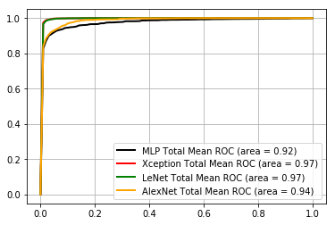

```python
%%time
# Great! Its seems we are also maxing out the F1 score, lets go with C==1e-3
from sklearn.metrics import roc_curve, auc
from scipy import interp
from sklearn.model_selection import StratifiedKFold

X_train, X_test, y_train, y_test = train_test_split(X, y, test_size=0.2, stratify=y, random_state=6)

X_train = X_train/255.0 - 0.5
X_test = X_test/255.0 - 0.5

# NEW: Let's start by fixing the sizes
X_train = np.expand_dims(X_train.reshape((-1,img_wh,img_wh)), axis=3)
X_test = np.expand_dims(X_test.reshape((-1,img_wh,img_wh)), axis=3)
# the image data has been resized to (samples,image_rows,image_cols,image_channels)

# and one hot encoding the output values
y_train_ohe = keras.utils.to_categorical(y_train, NUM_CLASSES)
y_test_ohe = keras.utils.to_categorical(y_test, NUM_CLASSES)

print(X_train.shape)
print(X_test.shape)

print("ROC")

####################### MLP ###########################
mean_tpr = 0.0
mean_fpr = np.linspace(0, 1, 100)
all_tpr = []

for i, (train, test) in enumerate(skf.split(X_train_mlp, y_train_mlp)):
    mlp.compile(loss='mean_squared_error',
              optimizer='rmsprop',
              metrics=[f1])
    mlp.fit(X_train_mlp[train], y_train_ohe_mlp[train], batch_size=128,
            epochs=20, shuffle=True, verbose=0)
    probas = mlp.predict(X_train_mlp[test])

    perclass_mean_tpr = 0.0
    roc_auc = 0
    classes = np.unique(y_train_mlp[train])
    # get the mean fpr and tpr, per class
    for j in classes:
        fpr, tpr, thresholds = roc_curve(y_train_mlp[test],
                                         probas[:, j],
                                         pos_label=j)
        perclass_mean_tpr += interp(mean_fpr, fpr, tpr)
        perclass_mean_tpr[0] = 0.0
        roc_auc += auc(fpr, tpr)

    perclass_mean_tpr /= len(classes)
    roc_auc /= len(classes)
    mean_tpr += perclass_mean_tpr
mean_tpr /= n_folds
mean_auc = auc(mean_fpr, mean_tpr)
plt.plot(mean_fpr,perclass_mean_tpr,'k-',lw=2,color='black',
         label='MLP Total Mean ROC (area = %0.2f)'
                   % (mean_auc))

########################### Xception ###############
mean_tpr = 0.0
mean_fpr = np.linspace(0, 1, 100)
all_tpr = []

for i, (train, test) in enumerate(skf.split(X_train, y_train)):
    xception_model.compile(loss='categorical_crossentropy', # 'categorical_crossentropy' 'mean_squared_error'
                optimizer='adam', # 'adadelta' 'rmsprop'
                metrics=[f1])
    xception_model.fit(X_train[train], y_train_ohe[train], batch_size=128, epochs=20, verbose=0)
    probas = xception_model.predict(X_train[test])
    perclass_mean_tpr = 0.0
    roc_auc = 0
    classes = np.unique(y_train[train])
    # get the mean fpr and tpr, per class
    for j in classes:
        fpr, tpr, thresholds = roc_curve(y_train[test],
                                         probas[:, j],
                                         pos_label=j)
        perclass_mean_tpr += interp(mean_fpr, fpr, tpr)
        perclass_mean_tpr[0] = 0.0
        roc_auc += auc(fpr, tpr)

    perclass_mean_tpr /= len(classes)
    roc_auc /= len(classes)
    mean_tpr += perclass_mean_tpr

mean_tpr /= n_folds
mean_auc = auc(mean_fpr, mean_tpr)
plt.plot(mean_fpr,perclass_mean_tpr,'k-',lw=2,color='red',
         label='Xception Total Mean ROC (area = %0.2f)'
                   % (mean_auc))

########################### ResNet ###############
mean_tpr = 0.0
mean_fpr = np.linspace(0, 1, 100)
all_tpr = []

for i, (train, test) in enumerate(skf.split(X_train, y_train)):
    resnet.compile(loss='categorical_crossentropy', # 'categorical_crossentropy' 'mean_squared_error'
                optimizer='adam', # 'adadelta' 'rmsprop'
                metrics=[f1])
    resnet.fit(X_train[train], y_train_ohe[train], batch_size=128, epochs=20, verbose=0)
    probas = resnet.predict(X_train[test])
    perclass_mean_tpr = 0.0
    roc_auc = 0
    classes = np.unique(y_train[train])
    # get the mean fpr and tpr, per class
    for j in classes:
        fpr, tpr, thresholds = roc_curve(y_train[test],
                                         probas[:, j],
                                         pos_label=j)
        perclass_mean_tpr += interp(mean_fpr, fpr, tpr)
        perclass_mean_tpr[0] = 0.0
        roc_auc += auc(fpr, tpr)

    perclass_mean_tpr /= len(classes)
    roc_auc /= len(classes)
    mean_tpr += perclass_mean_tpr

mean_tpr /= n_folds
mean_auc = auc(mean_fpr, mean_tpr)
plt.plot(mean_fpr,perclass_mean_tpr,'k-',lw=2,color='green',
         label='LeNet Total Mean ROC (area = %0.2f)'
                   % (mean_auc))

########################### AlexNet ###############
mean_tpr = 0.0
mean_fpr = np.linspace(0, 1, 100)
all_tpr = []

for i, (train, test) in enumerate(skf.split(X_train, y_train)):
    alex_net.compile(loss='categorical_crossentropy', # 'categorical_crossentropy' 'mean_squared_error'
              optimizer='rmsprop', # 'adadelta' 'rmsprop'
              metrics=[f1])
    alex_net.fit(X_train[train], y_train_ohe[train], batch_size=128, epochs=20, verbose=0)
    probas = alex_net.predict(X_train[test])
    perclass_mean_tpr = 0.0
    roc_auc = 0
    classes = np.unique(y_train[train])
    # get the mean fpr and tpr, per class
    for j in classes:
        fpr, tpr, thresholds = roc_curve(y_train[test],
                                         probas[:, j],
                                         pos_label=j)
        perclass_mean_tpr += interp(mean_fpr, fpr, tpr)
        perclass_mean_tpr[0] = 0.0
        roc_auc += auc(fpr, tpr)

    perclass_mean_tpr /= len(classes)
    roc_auc /= len(classes)
    mean_tpr += perclass_mean_tpr

mean_tpr /= n_folds
mean_auc = auc(mean_fpr, mean_tpr)
plt.plot(mean_fpr,perclass_mean_tpr,'k-',lw=2,color='orange',
         label='AlexNet Total Mean ROC (area = %0.2f)'
                   % (mean_auc))

plt.legend(loc='best')
plt.grid()
```

Inside each fold, for each class, we calculate its ROC curve and we use macro technique to get an average ROC curve. The reason why we use macro technique is that we don't have a particular weight for each class, we treaty each class equally. And for each fold, we calculate its ROC curve and then we calculate average ROC and AUC among all 10 folds.  
As what the ROC graph above shows, Xception/ResNet(Lenet) architecture(0.97) has a larger area under the curve, which is better than Alexnet(0.94) and standard MLP(0.92), which means all three architecture(Resnet, Xception, Alex) performs better than Multilayer Perceptron.

# 3. Exceptional work(10 points total)

#### You have free reign to provide additional analyses. One idea (required for 7000 level students): Use transfer learning to pre-train the weights of your initial layers of your CNN. Compare the performance when using transfer learning to training from scratch in terms of classification performance.

```python
X_train, X_test, y_train, y_test = train_test_split(X, y, test_size=0.2,
                                                   random_state=20, stratify=y)

X_train = X_train/255.0 - 0.5
X_test = X_test/255.0 - 0.5

print(X_train.shape)
print(X_test.shape)

X_train = np.expand_dims(X_train.reshape((-1,img_wh,img_wh)), axis=3)
X_test = np.expand_dims(X_test.reshape((-1,img_wh,img_wh)), axis=3)

y_train_ohe = keras.utils.to_categorical(y_train, NUM_CLASSES)
y_test_ohe = keras.utils.to_categorical(y_test, NUM_CLASSES)

print(X_train.shape)
print(X_test.shape)
```

```
(28709, 2304)
(7178, 2304)
(28709, 48, 48, 1)
(7178, 48, 48, 1)
```

```python
from scipy.misc import imresize
from skimage.transform import resize
import numpy as np
import skimage

# convert the gray scale image to rgb (3 channels)

x_train_up = [skimage.color.gray2rgb(np.resize(x, (48,48)))
              for x in X_train]
# x_train_up = [resize(x, output_shape=(48,48,3)) for x in X_train]
x_train_up = np.stack(x_train_up, axis=0)
print(x_train_up.shape)

x_test_up = [skimage.color.gray2rgb(np.resize(x, (48,48)))
             for x in X_test]
x_test_up = np.stack(x_test_up, axis=0)
print(x_test_up.shape)
```

```
(28709, 48, 48, 3)
(7178, 48, 48, 3)
```

Our image dataset is grey scale which only have one channel. So we need to convert our dataset into 3 channels using skimage.color.gray2rgb function.

```python
# connect new layers to the output
from keras.applications.densenet import DenseNet201
from keras.applications.densenet import preprocess_input, decode_predictions

# load only convolutional layers of resnet:
DenseNet201_no_top = DenseNet201(weights='imagenet', include_top=False)

x = x_train_up[0]
x = np.expand_dims(x, axis=0)
x = preprocess_input(x)
%time preds = DenseNet201_no_top.predict(x)
preds.shape
```

```
CPU times: user 4.68 s, sys: 203 ms, total: 4.88 s
Wall time: 4.88 s
```

```
(1, 1, 1, 1920)
```

```python
# pre-process the input data
x_train_up = preprocess_input(x_train_up)
x_test_up = preprocess_input(x_test_up)
```

```python
%%time

x_train_DenseNet201 = DenseNet201_no_top.predict(x_train_up)
x_test_DenseNet201 = DenseNet201_no_top.predict(x_test_up)
print(x_train_DenseNet201.shape)
```

```
(28709, 1, 1, 1920)
CPU times: user 43.7 s, sys: 5.4 s, total: 49.1 s
Wall time: 47.3 s
```

We choose DenseNet201 as our pre-trained network here.

```python
from keras.layers import SeparableConv2D
from keras.layers.normalization import BatchNormalization
from keras.layers import Add, Flatten, Dense
from keras.layers import average, concatenate
from keras.models import Input, Model


# let's add a fully-connected layer
input_x = Input(shape=x_train_DenseNet201[0].shape)
x = Flatten()(input_x)
x = Dense(200, activation='relu',kernel_initializer='he_uniform')(x)
x = Dense(200, activation='relu',kernel_initializer='he_uniform')(x)
x = Dense(200, activation='relu',kernel_initializer='he_uniform')(x)
predictions = Dense(NUM_CLASSES, activation='softmax', kernel_initializer='glorot_uniform')(x)

model = Model(inputs=input_x, outputs=predictions)

model.summary()
```

```
_________________________________________________________________
Layer (type)                 Output Shape              Param #
=================================================================
input_11 (InputLayer)        (None, 1, 1, 1920)        0
_________________________________________________________________
flatten_12 (Flatten)         (None, 1920)              0
_________________________________________________________________
dense_37 (Dense)             (None, 200)               384200
_________________________________________________________________
dense_38 (Dense)             (None, 200)               40200
_________________________________________________________________
dense_39 (Dense)             (None, 200)               40200
_________________________________________________________________
dense_40 (Dense)             (None, 7)                 1407
=================================================================
Total params: 466,007
Trainable params: 466,007
Non-trainable params: 0
_________________________________________________________________
```

After we setup the pre-trained model, we add three dense layers into the pre-trained model.

```python
# fit the data with pre-trained model

y_train_ohe_DenseNet201 = y_train_ohe[:x_train_DenseNet201.shape[0]]

model.compile(optimizer='rmsprop',
              loss='categorical_crossentropy',
              metrics=[f1])

tl_history = model.fit(x_train_DenseNet201, y_train_ohe_DenseNet201,
                       epochs=50,
                       batch_size=128,
                       verbose=1,
                       validation_data=(x_test_DenseNet201, y_test_ohe[:x_test_DenseNet201.shape[0]])
                       )
```

```
Train on 28709 samples, validate on 7178 samples
```

After feeding data into this network, we can see it's not so good. So will train another 50 iterations.

```python
tl_history = model.fit(x_train_DenseNet201, y_train_ohe_DenseNet201,
                       epochs=50,
                       batch_size=128,
                       verbose=1,
                       validation_data=(x_test_DenseNet201, y_test_ohe[:x_test_DenseNet201.shape[0]])
                       )
```

```
Train on 28709 samples, validate on 7178 samples
```

```python
alex_net.compile(loss='categorical_crossentropy', # 'categorical_crossentropy' 'mean_squared_error'
                 optimizer='rmsprop', # 'adadelta' 'rmsprop'
                 metrics=[f1])
resnet.compile(loss='categorical_crossentropy', # 'categorical_crossentropy' 'mean_squared_error'
               optimizer='adam', # 'adadelta' 'rmsprop'
               metrics=[f1])
xception_model.compile(loss='categorical_crossentropy', # 'categorical_crossentropy' 'mean_squared_error'
                       optimizer='adam', # 'adadelta' 'rmsprop'
                       metrics=[f1])
model.compile(optimizer='rmsprop',
              loss='categorical_crossentropy',
              metrics=[f1])
models = [alex_net, resnet, xception_model, model]

scores = []
for model_each in models:
    score_temp = []
    kFold = StratifiedKFold(n_splits=10, random_state=1).split(X_train, y_train)
    for k, (train, test) in enumerate(kFold):
        if model_each == model:
            model_each.fit(x_train_DenseNet201[train], y_train_ohe_DenseNet201[train], epochs=30, batch_size=128, verbose=0)
            yhat = np.argmax(model_each.predict(x_train_DenseNet201[test]), axis=1)
        else:
            model_each.fit(X_train[train], y_train_ohe[train], epochs=30, batch_size=128, verbose=0)
            yhat = np.argmax(model_each.predict(X_train[test]), axis=1)
        score = mt.f1_score(y_train[test], yhat, average='macro')
        score_temp += [score]
    scores.append(score_temp)
```

```python
file = open('scores_tl_dome5.txt','a')
for i in range(len(scores)):
    s = str(scores[i]).replace('[','').replace(']','')
    s = s.replace(',','') +'\n'
    file.write(s)
file.close()
```

```python
file = open("scores_tl_dome5.txt", 'r')
score_full = []
for line in file:
    line = line.replace('\n', '')
    score_temp = line.split(' ')
    score_full.append(list(map(lambda x: float(x), score_temp)))
file.close()
print(score_full)
```

```
[[0.5009456013382143, 0.6273711451342961, 0.7398241777349343, 0.7536925034994896, 0.7820253585570042, 0.7907148574091705, 0.7885976037184097, 0.8838056059533959, 0.6482112358944825, 0.8169997323952076], [0.527401751221164, 0.691199341836883, 0.7917371352355775, 0.8670149320522108, 0.9087598955230687…
```

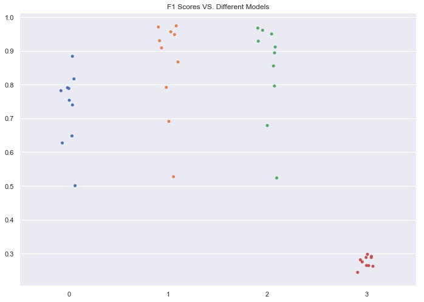

```python
f1_score, y_test, yhat = summarize_net(model, x_test_DenseNet201, y_test[:x_test_DenseNet201.shape[0]])
y_test = [i for i in y_test]
y_hat = [i for i in yhat]
with open('DenseNet201_model_demo5.txt', 'a') as f:
    f.write(str(y_test).replace('[', '').replace(']', '').replace(',', '').strip())
    f.write('\n')
    f.write(str(y_hat).replace('[', '').replace(']', '').replace(',', '').strip())
```

```python
print(f1_score)
```

```
0.23875633261802903
```

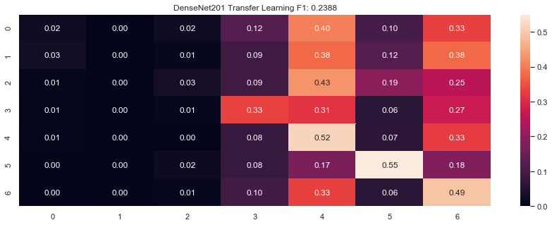

Like before, we used 20% test data which has never been seen to test final performance of the DenseNet201 model. We used sklearn confusion matrix evaluate performance of test data.  
From the heatmap above we can see, Densenet201 Transfer Learning perfomes terribly. It even cannot classify data into 0=Angry, 1=Disgust, 2=Fear. For class 3=Happy and 5=Surprise which has a good performance for the other three models, DenseNet201 has a terrible performance.

As we can see above, the pre-trained DenseNet201 model has a terrible performance on our dataset, which has only 0.2 f1_socres. We think one of the reason of the bad performance of this pre-trained model is that our dataset is originally gray scale images which have only one channel. However, the 'ImageNet' that is used to pre-train the model has 3 channels in each image of it. The image size of our dataset 48x48 pixels in 1 channel (48,48,1), but there was a error when we tried to fit them into the model which is 'the input_6 layer requires to be (None, None, 3)'. In order to meet the requirement, we 'had to' convert the gray scale image into RGB style. As a result, the performance drops dramatically.